# Enunciado Caso Práctico 1

## ¿Cómo lograr el éxito rápido de un negocio de bicicletas compartidas?

### **Escenario**

#### Eres un analista de datos júnior que trabaja en el equipo de analistas de marketing de Cyclistic, una empresa de bicicletas compartidas de Chicago. La directora de marketing cree que el éxito futuro de la empresa depende de maximizar la cantidad de membresías anuales. Por lo tanto, tu equipo quiere entender qué diferencias existen en el uso de las bicicletas Cyclistic entre los ciclistas ocasionales y los miembros anuales. A través de estos conocimientos, tu equipo diseñará una nueva estrategia de marketing para convertir a los ciclistas ocasionales en miembros anuales. Sin embargo, antes de eso, los ejecutivos de Cyclistic deben aprobar tus recomendaciones; por eso, debes respaldar tu propuesta con una visión convincente de los datos y visualizaciones profesionales de los mismos.

### **Personajes y equipos**

#### ● Cyclistic: Un programa de bicicletas compartidas que incluye 5,800 bicicletas y 600 estaciones. Cyclistic se destaca por ofrecer también bicicletas reclinadas, triciclos manuales y bicicletas de carga que ofrecen un uso más inclusivo de las bicicletas compartidas para las personas con discapacidad y los ciclistas que no pueden utilizar una bicicleta estándar de dos ruedas. La mayoría de los ciclistas eligen las bicicletas tradicionales, alrededor de un 8% de los ciclistas usan las opciones asistidas. Los usuarios de Cyclistic son más propensos a utilizar la bicicleta para recreación, pero alrededor del 30% la utiliza para ir al trabajo cada día.

#### ● Lily Moreno: La directora de marketing y tu gerente. Moreno es responsable del desarrollo de campañas e iniciativas para promover el programa de bicicletas compartidas. Las campañas pueden incluir correo electrónico, redes sociales y otros canales.

#### ● Equipo de análisis computacional de datos de marketing de Cyclistic: Un equipo de analistas de datos que se encargan de recopilar, analizar e informar datos que ayudan a conducir la estrategia de marketing de Cyclistic. Te incorporaste a este equipo hace seis meses y te has dedicado no solo a conocer la misión y las metas de negocios de Cyclistic, sino también a ver cómo puedes ayudar a Cyclistic a lograrlo, desde tu posición de analista de datos júnior.

#### ● Equipo ejecutivo de Cyclistic: El equipo ejecutivo, sumamente detallista, decidirá si aprueba el programa de marketing recomendado.

### **Acerca de la empresa**

#### En 2016, Cyclistic lanzó una exitosa oferta de bicicletas compartidas. Desde entonces, el programa creció hasta alcanzar una flota de 5,824 bicicletas georreferenciadas y bloqueadas en una red de 692 estaciones en toda Chicago. Las bicicletas se pueden desbloquear desde una estación y devolverse en cualquier otra estación del sistema en cualquier momento.

#### Hasta ahora, la estrategia de marketing de Cyclistic se basaba en la construcción de un reconocimiento de marca general y en atraer a amplios segmentos de consumidores. Uno de los enfoques que ayudó a hacer esto posible fue la flexibilidad de sus planes de precios: pases de un solo viaje, pases de un día completo y membresías anuales. A los clientes que compran pases de un solo viaje o pases de un día completo se los llama ciclistas ocasionales. Los clientes que compran membresías anuales se llaman miembros de Cyclistic.

#### Los analistas financieros de Cyclistic llegaron a la conclusión de que los miembros anuales son mucho más rentables que los ciclistas ocasionales. Aunque la flexibilidad de precios ayuda a Cyclistic a atraer más clientes, Moreno cree que maximizar el número de miembros anuales será clave para el crecimiento futuro. En lugar de crear una campaña de marketing que apunte a todos los clientes nuevos, Moreno cree que hay muchas posibilidades de convertir a los ciclistas ocasionales en miembros. Ella señala que los ciclistas ocasionales ya conocen el programa de Cyclistic y han elegido a Cyclistic para sus necesidades de movilidad.

#### Moreno estableció una meta clara: Diseñar estrategias de marketing orientadas a convertir a los ciclistas ocasionales en miembros anuales. Sin embargo, para hacer eso, el equipo de analistas de marketing necesita entender mejor cómo difieren los miembros anuales y los ciclistas ocasionales, por qué los ciclistas ocasionales comprarían una membresía y cómo los medios digitales podrían afectar sus tácticas de marketing. Moreno y su equipo están interesados en analizar los datos históricos de viajes en bicicleta de Cyclistic para identificar tendencias.

##### **NOTA:** Los datos históricos de los viajes de Cyclistic para analizar e identificar tendencias: [Descarga los datos de viajes de Cyclistic aquí](https://divvy-tripdata.s3.amazonaws.com/index.html). (Nota: Los conjuntos de datos tienen un nombre diferente porque Cyclistic es una empresa ficticia. A los fines de este caso práctico, los conjuntos de datos son apropiados y te permitirán responder las preguntas de la empresa. Los datos han sido proporcionados por Motivate International Inc. bajo esta [licencia](https://divvybikes.com/data-license-agreement).) Estos son datos públicos que puedes usar para explorar cómo difieren los tipos de clientes que usan las bicicletas Cyclistic. Sin embargo, ten en cuenta que, por cuestiones de privacidad de los datos, se te prohíbe usar información de identificación personal de los ciclistas. Esto significa que no podrás conectar las compras de pases con los números de tarjetas de crédito para determinar si los ciclistas ocasionales viven en el área de servicio de Cyclistic o si compraron varios pases de un solo viaje.

# [Click para ver análisis por "meses"](https://skibadeejcl.github.io/caso_practico_mes/)

# Caso práctico final - Análisis por días de la semana

Eduardo Castillo Lara

2024-02-18

# PASO 1: RECOLECCIÓN DE DATOS

# Se subieron a la plataforma, datos de los 12 meses (archivos csv), desde febrero del 2023 a enero del 2024, según lo sugerido por la actividad

```r
mes202302 <- read_csv("202302-divvy-tripdata.csv")
mes202303 <- read_csv("202303-divvy-tripdata.csv")
```

```r
mes202304 <- read_csv("202304-divvy-tripdata.csv")
```

```r
mes202305 <- read_csv("202305-divvy-tripdata.csv")
```

```r
mes202306 <- read_csv("202306-divvy-tripdata.csv")
```

```r
mes202307 <- read_csv("202307-divvy-tripdata.csv")
```

```r
mes202308 <- read_csv("202308-divvy-tripdata.csv")
```

```r
mes202309 <- read_csv("202309-divvy-tripdata.csv")
```

```r
mes202310 <- read_csv("202310-divvy-tripdata.csv")
```

```r
mes202311 <- read_csv("202311-divvy-tripdata.csv")
```

```r
mes202312 <- read_csv("202312-divvy-tripdata.csv")
```

```r
mes202401 <- read_csv("202401-divvy-tripdata.csv")
```

# PASO 2: VERIFICAR COMPATIBILIDAD DE DATOS Y POSTERIOR UNIFICACIÓN DE DATA FRAME

## Se comparan los nombres de las columnas de cada archivo CSV, éstos eran compatibles perfectamente (todos compartían las mismas columnas), por lo que no fue necesario modificar sus nombre en ninguno de estos.

```r
colnames(mes202302)
```

```
##  [1] "ride_id"            "rideable_type"      "started_at"
##  [4] "ended_at"           "start_station_name" "start_station_id"
##  [7] "end_station_name"   "end_station_id"     "start_lat"
## [10] "start_lng"          "end_lat"            "end_lng"
## [13] "member_casual"
```

```r
colnames(mes202303)
```

```r
colnames(mes202304)
```

```r
colnames(mes202305)
```

```r
colnames(mes202306)
```

```r
colnames(mes202307)
```

```r
colnames(mes202308)
```

```r
colnames(mes202309)
```

```r
colnames(mes202310)
```

```r
colnames(mes202311)
```

```r
colnames(mes202312)
```

```r
colnames(mes202401)
```

## Inspección de los dataframes y observar incongruencias (no las hubo)

```r
str(mes202302)
```

```
## spc_tbl_ [190,445 × 13] (S3: spec_tbl_df/tbl_df/tbl/data.frame)
##  $ ride_id           : chr [1:190445] "CBCD0D7777F0E45F" "F3EC5FCE5FF39DE9" "E54C1F27FA9354FF" "3D561E04F739CC45" ...
##  $ rideable_type     : chr [1:190445] "classic_bike" "electric_bike" "classic_bike" "electric_bike" ...
##  $ started_at        : POSIXct[1:190445], format: "2023-02-14 11:59:42" "2023-02-15 13:53:48" ...
##  $ ended_at          : POSIXct[1:190445], format: "2023-02-14 12:13:38" "2023-02-15 13:59:08" ...
##  $ start_station_name: chr [1:190445] "Southport Ave & Clybourn Ave" "Clarendon Ave & Gordon Ter" "Southport Ave & Clybourn Ave" "Southport Ave & Clybourn Ave" ...
##  $ start_station_id  : chr [1:190445] "TA1309000030" "13379" "TA1309000030" "TA1309000030" ...
##  $ end_station_name  : chr [1:190445] "Clark St & Schiller St" "Sheridan Rd & Lawrence Ave" "Aberdeen St & Monroe St" "Franklin St & Adams St (Temp)" ...
##  $ end_station_id    : chr [1:190445] "TA1309000024" "TA1309000041" "13156" "TA1309000008" ...
##  $ start_lat         : num [1:190445] 41.9 42 41.9 41.9 41.8 ...
##  $ start_lng         : num [1:190445] -87.7 -87.6 -87.7 -87.7 -87.6 ...
##  $ end_lat           : num [1:190445] 41.9 42 41.9 41.9 41.8 ...
##  $ end_lng           : num [1:190445] -87.6 -87.7 -87.7 -87.6 -87.6 ...
##  $ member_casual     : chr [1:190445] "casual" "casual" "member" "member" ...
##  - attr(*, "spec")=
##   .. cols(
##   ..   ride_id = col_character(),
##   ..   rideable_type = col_character(),
##   ..   started_at = col_datetime(format = ""),
##   ..   ended_at = col_datetime(format = ""),
##   ..   start_station_name = col_character(),
##   ..   start_station_id = col_character(),
##   ..   end_station_name = col_character(),
##   ..   end_station_id = col_character(),
##   ..   start_lat = col_double(),
##   ..   start_lng = col_double(),
##   ..   end_lat = col_double(),
##   ..   end_lng = col_double(),
##   ..   member_casual = col_character()
##   .. )
##  - attr(*, "problems")=<externalptr>
```

```r
str(mes202303)
```

```r
str(mes202304)
```

```r
str(mes202305)
```

```r
str(mes202306)
```

```r
str(mes202307)
```

```r
str(mes202308)
```

```r
str(mes202309)
```

```r
str(mes202310)
```

```r
str(mes202311)
```

```r
str(mes202312)
```

```r
str(mes202401)
```

## Unificación de archivos CSV en un único dataframe gigante (alrededor de 6 millones de filas)

```r
all_trips <- bind_rows(mes202302, mes202303, mes202304, mes202305, mes202306, mes202307,
                       mes202308, mes202309, mes202310, mes202311, mes202312, mes202401)
```

# PASO 3: LIMPIEZA E INSERCIÓN DE DATOS PARA PREPARAR EL ANÁLSIS

## Inspección del nuevo gran dataframe creado

```r
colnames(all_trips)
```

```
##  [1] "ride_id"            "rideable_type"      "started_at"
##  [4] "ended_at"           "start_station_name" "start_station_id"
##  [7] "end_station_name"   "end_station_id"     "start_lat"
## [10] "start_lng"          "end_lat"            "end_lng"
## [13] "member_casual"
```

```r
nrow(all_trips)
```

```
## [1] 5674449
```

```r
dim(all_trips)
```

```
## [1] 5674449      13
```

```r
head(all_trips)
```

```
## # A tibble: 6 × 13
##   ride_id          rideable_type started_at          ended_at
##   <chr>            <chr>         <dttm>              <dttm>
## 1 CBCD0D7777F0E45F classic_bike  2023-02-14 11:59:42 2023-02-14 12:13:38
## 2 F3EC5FCE5FF39DE9 electric_bike 2023-02-15 13:53:48 2023-02-15 13:59:08
## 3 E54C1F27FA9354FF classic_bike  2023-02-19 11:10:57 2023-02-19 11:35:01
## 4 3D561E04F739CC45 electric_bike 2023-02-26 16:12:05 2023-02-26 16:39:55
## 5 0CB4B4D53B2DBE05 electric_bike 2023-02-20 11:55:23 2023-02-20 12:05:48
## 6 C67EB62172C472EB classic_bike  2023-02-24 18:50:16 2023-02-24 18:56:40
## # ℹ 9 more variables: start_station_name <chr>, start_station_id <chr>,
## #   end_station_name <chr>, end_station_id <chr>, start_lat <dbl>,
## #   start_lng <dbl>, end_lat <dbl>, end_lng <dbl>, member_casual <chr>
```

```r
str(all_trips)
```

```
## spc_tbl_ [5,674,449 × 13] (S3: spec_tbl_df/tbl_df/tbl/data.frame)
##  $ ride_id           : chr [1:5674449] "CBCD0D7777F0E45F" "F3EC5FCE5FF39DE9" "E54C1F27FA9354FF" "3D561E04F739CC45" ...
##  $ rideable_type     : chr [1:5674449] "classic_bike" "electric_bike" "classic_bike" "electric_bike" ...
##  $ started_at        : POSIXct[1:5674449], format: "2023-02-14 11:59:42" "2023-02-15 13:53:48" ...
##  $ ended_at          : POSIXct[1:5674449], format: "2023-02-14 12:13:38" "2023-02-15 13:59:08" ...
##  $ start_station_name: chr [1:5674449] "Southport Ave & Clybourn Ave" "Clarendon Ave & Gordon Ter" "Southport Ave & Clybourn Ave" "Southport Ave & Clybourn Ave" ...
##  $ start_station_id  : chr [1:5674449] "TA1309000030" "13379" "TA1309000030" "TA1309000030" ...
##  $ end_station_name  : chr [1:5674449] "Clark St & Schiller St" "Sheridan Rd & Lawrence Ave" "Aberdeen St & Monroe St" "Franklin St & Adams St (Temp)" ...
##  $ end_station_id    : chr [1:5674449] "TA1309000024" "TA1309000041" "13156" "TA1309000008" ...
##  $ start_lat         : num [1:5674449] 41.9 42 41.9 41.9 41.8 ...
##  $ start_lng         : num [1:5674449] -87.7 -87.6 -87.7 -87.7 -87.6 ...
##  $ end_lat           : num [1:5674449] 41.9 42 41.9 41.9 41.8 ...
##  $ end_lng           : num [1:5674449] -87.6 -87.7 -87.7 -87.6 -87.6 ...
##  $ member_casual     : chr [1:5674449] "casual" "casual" "member" "member" ...
##  - attr(*, "spec")=
##   .. cols(
##   ..   ride_id = col_character(),
##   ..   rideable_type = col_character(),
##   ..   started_at = col_datetime(format = ""),
##   ..   ended_at = col_datetime(format = ""),
##   ..   start_station_name = col_character(),
##   ..   start_station_id = col_character(),
##   ..   end_station_name = col_character(),
##   ..   end_station_id = col_character(),
##   ..   start_lat = col_double(),
##   ..   start_lng = col_double(),
##   ..   end_lat = col_double(),
##   ..   end_lng = col_double(),
##   ..   member_casual = col_character()
##   .. )
##  - attr(*, "problems")=<externalptr>
```

```r
summary(all_trips)
```

```
##    ride_id          rideable_type        started_at
##  Length:5674449     Length:5674449     Min.   :2023-02-01 00:01:34.00
##  Class :character   Class :character   1st Qu.:2023-05-29 13:08:15.00
##  Mode  :character   Mode  :character   Median :2023-07-27 06:42:33.00
##                                        Mean   :2023-07-27 05:39:54.60
##                                        3rd Qu.:2023-09-24 08:33:28.00
##                                        Max.   :2024-01-31 23:59:40.00
##
##     ended_at                      start_station_name start_station_id
##  Min.   :2023-02-01 00:08:42.00   Length:5674449     Length:5674449
##  1st Qu.:2023-05-29 13:33:05.00   Class :character   Class :character
##  Median :2023-07-27 06:58:21.00   Mode  :character   Mode  :character
##  Mean   :2023-07-27 05:58:10.41
##  3rd Qu.:2023-09-24 08:59:02.00
##  Max.   :2024-02-02 00:01:21.00
##
##  end_station_name   end_station_id       start_lat       start_lng
##  Length:5674449     Length:5674449     Min.   :41.63   Min.   :-87.94
##  Class :character   Class :character   1st Qu.:41.88   1st Qu.:-87.66
##  Mode  :character   Mode  :character   Median :41.90   Median :-87.64
##                                        Mean   :41.90   Mean   :-87.65
##                                        3rd Qu.:41.93   3rd Qu.:-87.63
##                                        Max.   :42.07   Max.   :-87.46
##
##     end_lat         end_lng       member_casual
##  Min.   : 0.00   Min.   :-88.16   Length:5674449
##  1st Qu.:41.88   1st Qu.:-87.66   Class :character
##  Median :41.90   Median :-87.64   Mode  :character
##  Mean   :41.90   Mean   :-87.65
##  3rd Qu.:41.93   3rd Qu.:-87.63
##  Max.   :42.18   Max.   :  0.00
##  NA's   :7151    NA's   :7151
```

## Se revisa en la columna “member_casual” y “rideable_type”, que no existan incongruencias (está todo perfecto, no existen). NO se debe corregir ninguna de éstas.

```r
table(all_trips$member_casual)
```

```
##
##  casual  member
## 2043631 3630818
```

```r
table(all_trips$rideable_type)
```

```
##
##  classic_bike   docked_bike electric_bike
##       2682242         76549       2915658
```

## Se agregan columnas como la fecha, el mes, el día y el año de cada vuelta en bicicleta realizada. Esto nos permitirá agregar datos de viaje para cada mes, día o año (antes de completar estas operaciones solo se podría agregar a nivel de viaje).

```r
all_trips$date <- as.Date(all_trips$started_at) #El formato por defecto es yyyy-mm-dd
all_trips$month <- format(as.Date(all_trips$date), "%m")
all_trips$day <- format(as.Date(all_trips$date), "%d")
all_trips$year <- format(as.Date(all_trips$date), "%Y")
all_trips$day_of_week <- format(as.Date(all_trips$date), "%A")
```

## Se agrega la columna “ride_length” con la función difftime (en segundos), que calcula la diferencia entre el tiempo de partida con el tiempo de finalización de cada viaje.

```r
all_trips$ride_length <- difftime(all_trips$ended_at,all_trips$started_at)
```

## Se inspeccionan nuevamente la congruencia de las columnas

```r
str(all_trips)
```

```
## spc_tbl_ [5,674,449 × 19] (S3: spec_tbl_df/tbl_df/tbl/data.frame)
##  $ ride_id           : chr [1:5674449] "CBCD0D7777F0E45F" "F3EC5FCE5FF39DE9" "E54C1F27FA9354FF" "3D561E04F739CC45" ...
##  $ rideable_type     : chr [1:5674449] "classic_bike" "electric_bike" "classic_bike" "electric_bike" ...
##  $ started_at        : POSIXct[1:5674449], format: "2023-02-14 11:59:42" "2023-02-15 13:53:48" ...
##  $ ended_at          : POSIXct[1:5674449], format: "2023-02-14 12:13:38" "2023-02-15 13:59:08" ...
##  $ start_station_name: chr [1:5674449] "Southport Ave & Clybourn Ave" "Clarendon Ave & Gordon Ter" "Southport Ave & Clybourn Ave" "Southport Ave & Clybourn Ave" ...
##  $ start_station_id  : chr [1:5674449] "TA1309000030" "13379" "TA1309000030" "TA1309000030" ...
##  $ end_station_name  : chr [1:5674449] "Clark St & Schiller St" "Sheridan Rd & Lawrence Ave" "Aberdeen St & Monroe St" "Franklin St & Adams St (Temp)" ...
##  $ end_station_id    : chr [1:5674449] "TA1309000024" "TA1309000041" "13156" "TA1309000008" ...
##  $ start_lat         : num [1:5674449] 41.9 42 41.9 41.9 41.8 ...
##  $ start_lng         : num [1:5674449] -87.7 -87.6 -87.7 -87.7 -87.6 ...
##  $ end_lat           : num [1:5674449] 41.9 42 41.9 41.9 41.8 ...
##  $ end_lng           : num [1:5674449] -87.6 -87.7 -87.7 -87.6 -87.6 ...
##  $ member_casual     : chr [1:5674449] "casual" "casual" "member" "member" ...
##  $ date              : Date[1:5674449], format: "2023-02-14" "2023-02-15" ...
##  $ month             : chr [1:5674449] "02" "02" "02" "02" ...
##  $ day               : chr [1:5674449] "14" "15" "19" "26" ...
##  $ year              : chr [1:5674449] "2023" "2023" "2023" "2023" ...
##  $ day_of_week       : chr [1:5674449] "martes" "miércoles" "domingo" "domingo" ...
##  $ ride_length       : 'difftime' num [1:5674449] 836 320 1444 1670 ...
##   ..- attr(*, "units")= chr "secs"
##  - attr(*, "spec")=
##   .. cols(
##   ..   ride_id = col_character(),
##   ..   rideable_type = col_character(),
##   ..   started_at = col_datetime(format = ""),
##   ..   ended_at = col_datetime(format = ""),
##   ..   start_station_name = col_character(),
##   ..   start_station_id = col_character(),
##   ..   end_station_name = col_character(),
##   ..   end_station_id = col_character(),
##   ..   start_lat = col_double(),
##   ..   start_lng = col_double(),
##   ..   end_lat = col_double(),
##   ..   end_lng = col_double(),
##   ..   member_casual = col_character()
##   .. )
##  - attr(*, "problems")=<externalptr>
```

```r
is.factor(all_trips$ride_length)
```

```
## [1] FALSE
```

```r
all_trips$ride_length <- as.numeric(as.character(all_trips$ride_length))
is.numeric(all_trips$ride_length)
```

```
## [1] TRUE
```

## Se remueven los datos malos, específicamente los tiempos negativos en “ride_length” (ya que físicamente estos no pueden ser menores a cero, no existe el tiempo negativo), esto pudo ser ocasionado al hacer la diferencia entre los tiempos de partida y llegada.

## Para conservar el dataframe con los datos originales sin modificar, se creará una nueva tabla “all_trips-v2”, con los datos ya limpios.

```r
all_trips_v2 <- all_trips[!(all_trips$ride_length<0 ),]
```

# PASO 4: PARA REALIZAR EL ANÁLISIS DESCRIPTIVO

## Análisis descriptivo sobre “ride_length” (unidades en segundos)

```r
mean(all_trips_v2$ride_length) #Promedio ("ride_length" total/ número de vueltas)
```

```
## [1] 1096.799
```

```r
median(all_trips_v2$ride_length) #Mediana (punto medio en "ride_length")
```

```
## [1] 573
```

```r
max(all_trips_v2$ride_length) #Viaje más largo (en segundos)
```

```
## [1] 5909344
```

```r
min(all_trips_v2$ride_length) #Viaje más corto (en segundos)
```

```
## [1] 0
```

## Además se puede hacer un resumen más acotado con la función summary, obteniendo los mismos resultados anteriores.

```r
summary(all_trips_v2$ride_length)
```

```
##    Min. 1st Qu.  Median    Mean 3rd Qu.    Max.
##       0     326     573    1097    1018 5909344
```

## Comparación de usuarios “miembros” y “casuales”

```r
aggregate(all_trips_v2$ride_length ~ all_trips_v2$member_casual, FUN = mean)
```

```
##   all_trips_v2$member_casual all_trips_v2$ride_length
## 1                     casual                1696.1753
## 2                     member                 759.4467
```

```r
aggregate(all_trips_v2$ride_length ~ all_trips_v2$member_casual, FUN = median)
```

```
##   all_trips_v2$member_casual all_trips_v2$ride_length
## 1                     casual                      713
## 2                     member                      512
```

```r
aggregate(all_trips_v2$ride_length ~ all_trips_v2$member_casual, FUN = max)
```

```
##   all_trips_v2$member_casual all_trips_v2$ride_length
## 1                     casual                  5909344
## 2                     member                    93580
```

```r
aggregate(all_trips_v2$ride_length ~ all_trips_v2$member_casual, FUN = min)
```

```
##   all_trips_v2$member_casual all_trips_v2$ride_length
## 1                     casual                        0
## 2                     member                        0
```

## Promedio de tiempo de viaje para cada día de la semana, en relación a usuarios miembros vs casuales

```r
aggregate(all_trips_v2$ride_length ~ all_trips_v2$member_casual + all_trips_v2$day_of_week, FUN = mean)
```

```
##    all_trips_v2$member_casual all_trips_v2$day_of_week all_trips_v2$ride_length
## 1                      casual                  domingo                1965.9861
## 2                      member                  domingo                 846.8916
## 3                      casual                   jueves                1480.4407
## 4                      member                   jueves                 726.2820
## 5                      casual                    lunes                1669.9904
## 6                      member                    lunes                 722.5225
## 7                      casual                   martes                1514.1102
## 8                      member                   martes                 732.6067
## 9                      casual                miércoles                1461.9162
## 10                     member                miércoles                 730.8679
## 11                     casual                   sábado                1929.7851
## 12                     member                   sábado                 841.7642
## 13                     casual                  viernes                1637.2616
## 14                     member                  viernes                 751.9673
```

## Los días de la semana no están en órden, por lo que se procede a ordenarlos como corresponde (de Domingo a Sábado).

```r
all_trips_v2$day_of_week <- ordered(all_trips_v2$day_of_week, levels=c("domingo", "lunes", "martes", "miércoles", "jueves", "viernes", "sábado"))
```

## Una vez ordenados los días de la semana, se puede ejecutar el promedio de tiempos de viajes para cada día de la semana, en relación a usuarios miembros vs casuales.

```r
aggregate(all_trips_v2$ride_length ~ all_trips_v2$member_casual + all_trips_v2$day_of_week, FUN = mean)
```

```
##    all_trips_v2$member_casual all_trips_v2$day_of_week all_trips_v2$ride_length
## 1                      casual                  domingo                1965.9861
## 2                      member                  domingo                 846.8916
## 3                      casual                    lunes                1669.9904
## 4                      member                    lunes                 722.5225
## 5                      casual                   martes                1514.1102
## 6                      member                   martes                 732.6067
## 7                      casual                miércoles                1461.9162
## 8                      member                miércoles                 730.8679
## 9                      casual                   jueves                1480.4407
## 10                     member                   jueves                 726.2820
## 11                     casual                  viernes                1637.2616
## 12                     member                  viernes                 751.9673
## 13                     casual                   sábado                1929.7851
## 14                     member                   sábado                 841.7642
```

## Análisis de datos por tipo de usuario y días de la semana

```r
all_trips_v2 %>%
  mutate(dias = wday(started_at, label = TRUE)) %>%  #se crea campo "dias" con wday()
  group_by(member_casual, dias) %>%  #se agrupan por tipo de usuario y dias
  summarise(numero_de_viajes = n()       #se calcula el número de viajes y la duración promedio
            ,average_duration = mean(ride_length)) %>%  # calcula la duración promedio
  arrange(member_casual, dias)                              # ordena por tipos de usuario y dias
```

```
## # A tibble: 14 × 4
## # Groups:   member_casual [2]
##    member_casual dias     numero_de_viajes average_duration
##    <chr>         <ord>               <int>            <dbl>
##  1 casual        "dom\\."           331663            1966.
##  2 casual        "lun\\."           233173            1670.
##  3 casual        "mar\\."           242725            1514.
##  4 casual        "mié\\."           247759            1462.
##  5 casual        "jue\\."           269975            1480.
##  6 casual        "vie\\."           310002            1637.
##  7 casual        "sáb\\."           408190            1930.
##  8 member        "dom\\."           401873             847.
##  9 member        "lun\\."           491689             723.
## 10 member        "mar\\."           566292             733.
## 11 member        "mié\\."           588205             731.
## 12 member        "jue\\."           589610             726.
## 13 member        "vie\\."           525232             752.
## 14 member        "sáb\\."           467769             842.
```

## Visualización de número de viajes por cada tipo de usuario

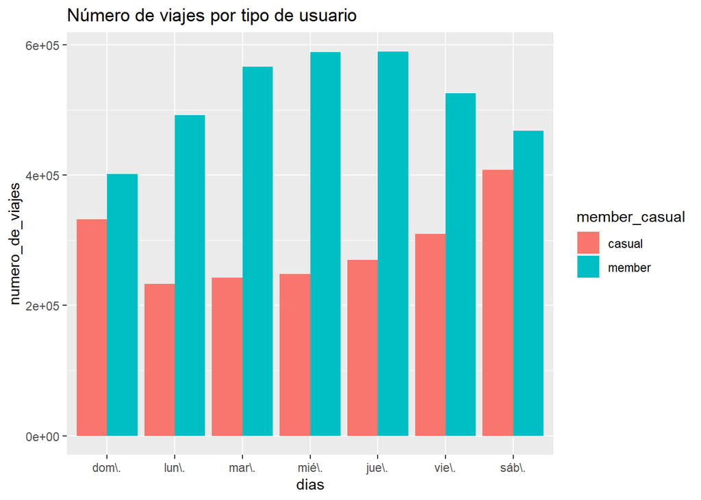

```r
all_trips_v2 %>%
  mutate(dias = wday(started_at, label = TRUE)) %>%
  group_by(member_casual, dias) %>%
  summarise(numero_de_viajes = n()
            ,average_duration = mean(ride_length)) %>%
  arrange(member_casual, dias)  %>%
  ggplot(aes(x = dias, y = numero_de_viajes, fill = member_casual)) +
  geom_col(position = "dodge") + labs(title="Número de viajes por tipo de usuario")
```

## Visualización de duración promedio por tipo de usuario

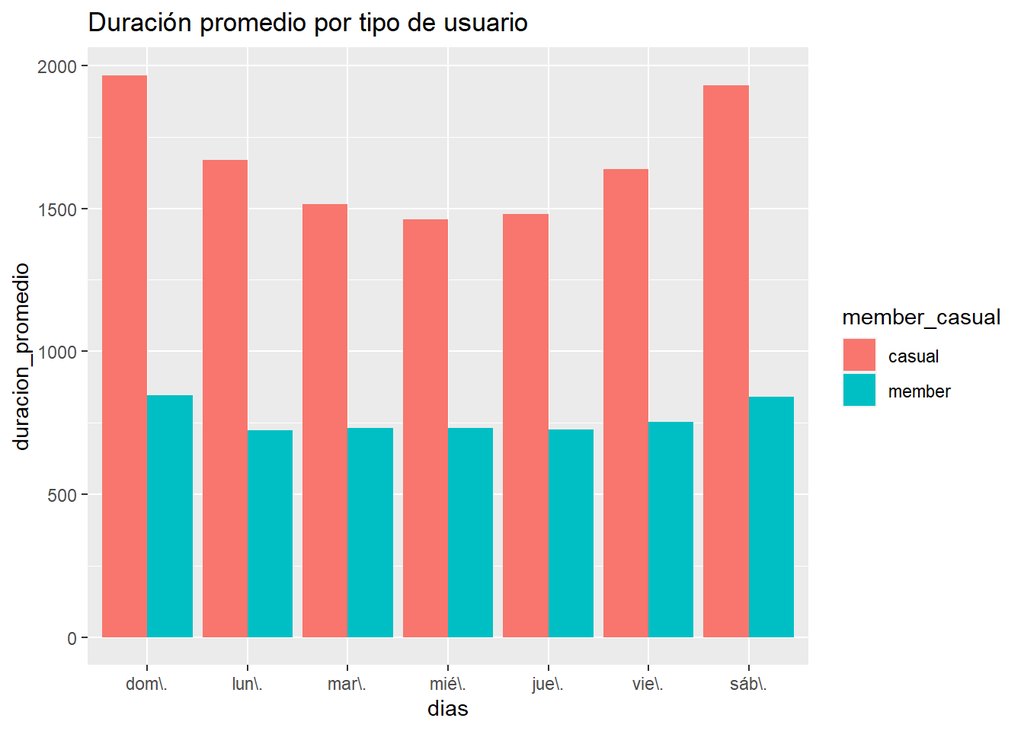

```r
all_trips_v2 %>%
  mutate(dias = wday(started_at, label = TRUE)) %>%
  group_by(member_casual, dias) %>%
  summarise(numero_de_viajes = n()
            ,duracion_promedio = mean(ride_length)) %>%
  arrange(member_casual, dias)  %>%
  ggplot(aes(x = dias, y = duracion_promedio, fill = member_casual)) +
  geom_col(position = "dodge") + labs(title="Duración promedio por tipo de usuario")
```

# PASO 5: ANÁLISIS

## Analizar la organización y el formateo de los datos

### *Para realizar la organización de los 12 CSV mensuales, me fijé que todos tuvieran la misma cantidad de columnas, con el mismo nombre e igual formato. Una vez que decidí que todos los datos y tablas no tuvieron incongruencias, usé la función bind_rows para unir todos los archivos en un solo gran Data Frame. Para mi sorpresa, los datos estaban tan bien estructurados, que no tuve la necesidad de hacer arreglos (como cambiar nombres a columnas en algún CSV, por ejemplo).*

## La historia de los datos

### *He creado 2 visualizaciónes, número de viajes por tipo de usuario y duración promedio por tipo de usuario. Para mi sorpresa, si bien es obvio que los usuarios miembros usaran el servicio en mayores oportunidades (más viajes), los usuarios ocasionales en promedio usaban las bicicletas por mayor duración.*

### *Usé visualizaciones de barras geom_col, debido a que los datos contenían los grupos y el recuento para cada uno de ellos. Si bien, en general, me gusta cómo se ve geom_point, para términos prácticos de esta actividad, decidí que geom_col posee atributos que hacen aún más legible los resultados. Pero en general, pretendo en un futuro aprender y usar toda la variedad de visualizaciones que posee ggplot (y sus diferentes opciones, como introducir títulos y subtítulos, cambiar colores, etc).*

## Resumen

### *Los datos adicionales que se podrían analizar para un estudio más acabado, podría ser el tráfico imperante en Chicago (ciudad de donde provienen los datos de las bicicletas) y las repercusiones en tiempos de traslado que talvez favorezcan el uso de vehículos no motorizados (e incluso el impacto ambiental que tendría esto, que podrían ser más datos adicionales a analizar). Todo esto, con la intensión de incentivar aún más el uso del servicio de Cyclistic a través de campañas de marketing.*

### *- Enfocar esfuerzos para campaña de marketing respecto a la salud VS transporte en bicicleta.*

### *- Los miembros ahorrarán más dinero que los ocasionales al mediano y largo plazo.*